# Olist電商資料探索

## 2.產品類別的特性比較

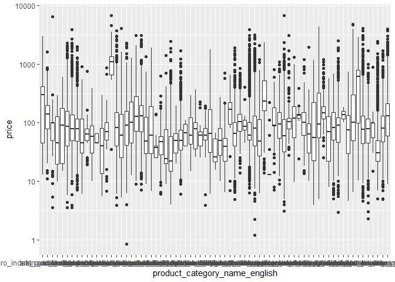

```r
ggplot(ProductSell,aes(x=product_category_name_english,y=price))+
  geom_boxplot()+
  scale_y_log10()
```

> 因為Review是針對一筆訂單，而訂單可能包含多項商品，我們不知道評論究竟是針對訂單中的哪一個產品，因此篩選出只有 買一個商品的訂單，可以確保評論的星等是針對此商品。

篩選出只有購買一個商品的訂單

```r
One_product = Item %>%
        group_by(order_id) %>%
        summarise(product_num = n_distinct(order_item_id)) %>%
        filter(product_num == 1)
```

以產品類別做分組 計算出平均單價、總收益、商品總賣出數、有多少賣家賣出此種產品類別

```r
X = ProductSell %>%
    filter(order_id %in% One_product$order_id) %>%  #篩選出只有購買一個商品的訂單
    group_by(product_category_name_english) %>%
    summarise(
      avg_price = mean(price), #平均單價
      total_rev = sum(price), #總收益
      total_sold_num = n(),　#商品總賣出數
      total_seller_num = n_distinct(seller_id),
      total_cust_num = n_distinct(customer_unique_id),
      avg_fre = mean(freight_value)
      #有多少賣家賣出此種產品類別
    ) %>% mutate()
```

以產品類別做分組 計算出總評論數量、平均評論分數

```r
ProductReview = ProductSell %>%
                filter(order_id %in% One_product$order_id) %>%
                left_join(Reviews) #保留那些沒有評論的商品
visCate = ProductReview %>%
  group_by(product_category_name_english) %>%
  summarise(
    total_review_num = n(), #評論數量
    avg_review_score = mean(review_score)) %>%
  merge(X) %>%
  mutate(dummy = 2018)
```

google motion chart

```r
op <- options(gvis.plot.tag='chart')
options(op)
vistmp = gvisMotionChart(
  visCate, "product_category_name_english", "dummy",
  options=list(width=800, height=600, title="Product category"))

print(vistmp, file="M.html")

includeHTML("./M.html")
```

Data: visCate • Chart ID: MotionChartID317096395b • [googleVis-0.6.3](https://github.com/mages/googleVis)  
R version 3.5.1 (2018-07-02) • [Google Terms of Use](https://developers.google.com/terms/) • [Documentation and Data Policy](https://google-developers.appspot.com/chart/interactive/docs/gallery/motionchart)

## 3.賣家所在地區（州）的特性比較

```r
X = ProductSell %>%
    filter(order_id %in% One_product$order_id) %>%  #篩選出只有購買一個商品的訂單
    group_by(seller_state) %>%
    summarise(
      avg_price = mean(price),
      total_rev = sum(price),
      total_sold_num = n(),
      total_seller_num = n_distinct(seller_id),
      total_cust_num = n_distinct(customer_unique_id),
      avg_fre = mean(freight_value)
    )

visState = ProductReview %>%
  group_by(seller_state) %>%
  summarise(
    total_review_num = n(), #評論數量
    avg_review_score = mean(review_score)) %>%
  merge(X) %>%
  mutate(dummy = 2018)
```

```r
op <- options(gvis.plot.tag='chart')
options(op)
vistmp = gvisMotionChart(
  visState, "seller_state", "dummy",
  options=list(width=800, height=600, title="Product category"))

print(vistmp, file="M.html")
includeHTML("./M.html")
```

Data: visState • Chart ID: MotionChartID317050b434ba • [googleVis-0.6.3](https://github.com/mages/googleVis)  
R version 3.5.1 (2018-07-02) • [Google Terms of Use](https://developers.google.com/terms/) • [Documentation and Data Policy](https://google-developers.appspot.com/chart/interactive/docs/gallery/motionchart)

### 地理繪圖

將州名縮寫對照到全名

```r
abbrBZ = read.csv("state.csv")
names(abbrBZ)[1] = "ABBR"
```

```r
vis = merge(visState,abbrBZ,by.x = "seller_state",by.y = "ABBR")
```

```r
GeoStates <- gvisGeoChart(vis,
                          locationvar = "State_name",

                          colorvar = "total_sold_num",
                          sizevar = "total_cust_num",
                          hovervar = "seller_state",
                          options=list(region="BR",
                                       displayMode="regions",
                                       resolution="provinces",
                          width=800, height=600))

print(GeoStates, file="geo.html")

includeHTML("./geo.html")
```

Data: vis • Chart ID: GeoChartID31703a5e61ca • [googleVis-0.6.3](https://github.com/mages/googleVis)  
R version 3.5.1 (2018-07-02) • [Google Terms of Use](https://developers.google.com/terms/) • [Documentation and Data Policy](https://google-developers.appspot.com/chart/interactive/docs/gallery/geochart)

## 4. 分群：以賣家銷售資料對賣家做分群 推測其產業類別

> 在marketing funnel中的Deal資料集中 有business_segment欄位說明賣家屬於哪個產業類別 但只有提供377多個商家有business_segment

```r
X = merge(Deal,ProductSell)
length(unique(X$seller_id))
```

```
[1] 377
```

原本的business_segment有幾種類別

```r
levels(Deal$business_segment)
```

```
 [1] ""                                "air_conditioning"
 [3] "audio_video_electronics"         "baby"
 [5] "bags_backpacks"                  "bed_bath_table"
 [7] "books"                           "car_accessories"
 [9] "computers"                       "construction_tools_house_garden"
[11] "fashion_accessories"             "food_drink"
[13] "food_supplement"                 "games_consoles"
[15] "gifts"                           "handcrafted"
[17] "health_beauty"                   "home_appliances"
[19] "home_decor"                      "home_office_furniture"
[21] "household_utilities"             "jewerly"
[23] "music_instruments"               "other"
[25] "party"                           "perfume"
[27] "pet"                             "phone_mobile"
[29] "religious"                       "small_appliances"
[31] "sports_leisure"                  "stationery"
[33] "toys"                            "watches"
```

> 所有我們嘗試對賣家做分群 並查看每群特性 推測其產業類別

分群的來源資料為 ProductSell:每一筆是一個賣家的商品銷售紀錄  
整理出一個dataframe  
每一列是一個賣家 欄位是每種產品種類的sold number

```r
Segment = table(ProductSell$seller_id,ProductSell$product_category_name_english) %>% as.data.frame
Segment = Segment %>% spread(Var2,Freq) #從長表格整理成寬表格
names(Segment)[1] = "seller_id"
```

只選取有銷售紀錄的賣家

```r
Segment = Segment[rowSums(Segment[,2:72]) != 0,]
```

## 分群找出產業類別

> 根據賣家銷售紀錄來對賣家做分群，我們對賣家銷售紀錄的處理方法有兩種

### 1. 0/1 沒賣/有賣 商品

> 將產品種類賣出數 轉成 只要有賣就是true , 沒賣是false 的格式 但我們認為這樣子會失去單一賣家的銷售特性

### 2.賣家銷售類別比例 來計算距離作分群

> 以prop.table(margin=1) 計算每個賣家銷售產品的類別比例

```r
mx = as.matrix(Segment[,2:72]) %>% prop.table(margin=1)
hc = dist(mx) %>% hclust(method="ward.D2")
```

> 在反覆測試分群數目後，選擇20作為最終分群數

[figure not shown]

```r
kg = cutree(hc, k=20)

cluster = as.data.frame(table(kg))

ggplot(cluster,aes(x=reorder(kg, -Freq), y = Freq)) +
    geom_bar(stat="identity")+
    labs(x="第幾群",y="群內賣家數量")
```

```r
mx = as.data.frame(mx)
mx$group = factor(cutree(hc, k=20))
```

```r
D = mx %>%
  group_by(group) %>%
  summarise_each(funs(mean))
```

> 以熱圖呈現每群特性：同一群賣家的銷售產品類別比例

```r
D[,2:72] %>%
  as.matrix %>%
d3heatmap(col=colorRampPalette(c('black','darkblue','blue','green','yellow','orange','red'))(999))
```

[interactive chart not shown]

> 先以第二種方法來看的話

### 每個產業類別有領導賣家嗎？

得到group id後 合併回去銷售資料

```r
X = ProductSell %>%
  group_by(seller_id) %>%
  summarise(
    total_sold_num = n(),
    total_rev = sum(price),
    avg_freight = mean(freight_value),
    prod_num = n_distinct(product_id),
    avg_photo_qty = mean(product_photos_qty)
  )
```

```r
Leader = cbind(X,mx[,"group"])
names(Leader)[7] = "group"
```

以x軸為賣家總賣出的商品數量 , y軸為總收益 看出有哪幾群出現領導賣家

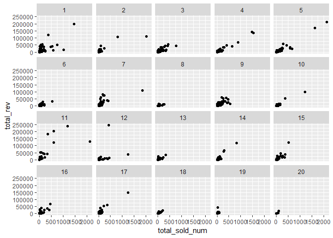

```r
ggplot(Leader,aes(x=total_sold_num,y=total_rev))+
  geom_point()+
  facet_wrap(.~group)
```

> 三個觀察點
- 1. 觀察不同市場中，廠商銷售數及其收益的關係。
- 2. 壟斷性競爭
  - 1. 不完全競爭市場
  - 2. 消費者偏好及品牌忠誠度
  - 3. 定價策略
- 3. 產業集中度
  - 1. 用于衡量產業競爭性和壟斷性的最常用指標。
  - 2. 產業集中度高，代表這家企業具有較大的市場力
  - 3. 領導廠商定價

## 5. 照片數量與銷售量的關係

### 家具類商品的googlevis

```r
X_furniture = ProductSell %>%
    filter(order_id %in% One_product$order_id) %>%  #篩選出只有購買一個商品的訂單
    filter(product_category_name_english == "furniture_decor") %>%
    group_by(product_id) %>%
    summarise(
      avg_price = mean(price),
      total_price = sum(price),
      total_sold_num = n(),
      total_seller_num = n_distinct(seller_id),
      photo_qty = mean(product_photos_qty)
    ) %>% mutate()
```

```r
vis_furniture = ProductSell %>%
  filter(order_id %in% One_product$order_id) %>%
  filter(product_category_name_english == "furniture_decor") %>%
  merge(Reviews) %>%
  group_by(product_id) %>%
  summarise(
    total_review_num = n(), #評論數量
    avg_review_score = mean(review_score)) %>%
  merge(X_furniture)
M = select(ProductSell, product_id, order_purchase_timestamp)
vis_furniture = merge(vis_furniture, M)
vis_furniture$order_purchase_timestamp = as.Date(vis_furniture$order_purchase_timestamp, format = "%Y-%m-%d %H:%M:%S")
vis_furniture = unique(vis_furniture)
```

```r
vistmp_furniture = gvisMotionChart(
  vis_furniture, "product_id", "order_purchase_timestamp",
  options = list(width = 800, height = 600, title = "product category")
)
print(vistmp_furniture, file = "Furniture.html")
```

## 食物類產品

```r
X_food = ProductSell %>%
    filter(order_id %in% One_product$order_id) %>%  #篩選出只有購買一個商品的訂單
    filter(product_category_name_english == "food") %>%
    group_by(product_id) %>%
    summarise(
      avg_price = mean(price),
      total_price = sum(price),
      total_sold_num = n(),
      total_seller_num = n_distinct(seller_id),
      photo_qty = mean(product_photos_qty)
    ) %>% mutate()
vis_food = ProductReview  %>%
  filter(order_id %in% One_product$order_id) %>%
  filter(product_category_name_english == "food") %>%
  merge(Reviews) %>%
  group_by(product_id) %>%
  summarise(
    total_review_num = n(), #評論數量
    avg_review_score = mean(review_score)) %>%
  merge(X_food)
M = select(ProductReview , product_id, order_purchase_timestamp)
vis_food = merge(vis_furniture, M)
vis_food$order_purchase_timestamp = as.Date(vis_food$order_purchase_timestamp, format = "%Y-%m-%d %H:%M:%S")
vis_food = unique(vis_food)

vistmp_food = gvisMotionChart(
  vis_food, "product_id", "order_purchase_timestamp",
  options=list(width=800, height=600, title="Product category") )


print(vistmp_food, file = "Food.html")
includeHTML("Food.html")
```

Data: vis_food • Chart ID: MotionChartID31707298359c • [googleVis-0.6.3](https://github.com/mages/googleVis)  
R version 3.5.1 (2018-07-02) • [Google Terms of Use](https://developers.google.com/terms/) • [Documentation and Data Policy](https://google-developers.appspot.com/chart/interactive/docs/gallery/motionchart)

## 寵物相關商品

```r
X_petshop = ProductSell %>%
    filter(order_id %in% One_product$order_id) %>%  #篩選出只有購買一個商品的訂單
    filter(product_category_name_english == "pet_shop") %>%
    group_by(product_id) %>%
    summarise(
      avg_price = mean(price),
      total_price = sum(price),
      total_sold_num = n(),
      total_seller_num = n_distinct(seller_id),
      photo_qty = mean(product_photos_qty)
    ) %>% mutate()
vis_petshop = ProductReview %>%
  filter(order_id %in% One_product$order_id) %>%
  filter(product_category_name_english == "pet_shop") %>%
  merge(Reviews) %>%
  group_by(product_id) %>%
  summarise(
    total_review_num = n(), #評論數量
    avg_review_score = mean(review_score)) %>%
  merge(X_petshop)
M = select(ProductReview, product_id, order_purchase_timestamp)
vis_petshop = merge(vis_petshop, M)
vis_petshop$order_purchase_timestamp = as.Date(vis_petshop$order_purchase_timestamp, format = "%Y-%m-%d %H:%M:%S")
vis_petshop = unique(vis_petshop)

vistmp_petshop = gvisMotionChart(
  vis_petshop, "product_id", "order_purchase_timestamp",
  options = list(width = 800, height = 600, title = "product category")
)
print(vistmp_petshop, file = "Petshop.html")
includeHTML("Petshop.html")
```

Data: vis_petshop • Chart ID: MotionChartID317014657ff8 • [googleVis-0.6.3](https://github.com/mages/googleVis)  
R version 3.5.1 (2018-07-02) • [Google Terms of Use](https://developers.google.com/terms/) • [Documentation and Data Policy](https://google-developers.appspot.com/chart/interactive/docs/gallery/motionchart)

## 手錶禮品類

```r
X_watch = ProductSell %>%
    filter(order_id %in% One_product$order_id) %>%  #篩選出只有購買一個商品的訂單
    filter(product_category_name_english == "watches_gifts") %>%
    group_by(product_id) %>%
    summarise(
      avg_price = mean(price),
      total_price = sum(price),
      total_sold_num = n(),
      total_seller_num = n_distinct(seller_id),
      photo_qty = mean(product_photos_qty)
    ) %>% mutate()
vis_watch = ProductReview %>%
  filter(order_id %in% One_product$order_id) %>%
  filter(product_category_name_english == "watches_gifts") %>%
  merge(Reviews) %>%
  group_by(product_id) %>%
  summarise(
    total_review_num = n(), #評論數量
    avg_review_score = mean(review_score)) %>%
  merge(X_watch)
M = select(ProductReview, product_id, order_purchase_timestamp)
vis_watch = merge(vis_watch, M)
vis_watch$order_purchase_timestamp = as.Date(vis_watch$order_purchase_timestamp, format = "%Y-%m-%d %H:%M:%S")
vis_watch = unique(vis_watch)

vistmp_watch = gvisMotionChart(
  vis_watch, "product_id", "order_purchase_timestamp",
  options = list(width = 800, height = 600, title = "product category")
)
print(vistmp_watch, file = "Watch.html")
includeHTML("Watch.html")
```

Data: vis_watch • Chart ID: MotionChartID3170f456c3b • [googleVis-0.6.3](https://github.com/mages/googleVis)  
R version 3.5.1 (2018-07-02) • [Google Terms of Use](https://developers.google.com/terms/) • [Documentation and Data Policy](https://google-developers.appspot.com/chart/interactive/docs/gallery/motionchart)

## 香水

```r
X_perfumery = ProductSell %>%
    filter(order_id %in% One_product$order_id) %>%  #篩選出只有購買一個商品的訂單
    filter(product_category_name_english == "perfumery") %>%
    group_by(product_id) %>%
    summarise(
      avg_price = mean(price),
      total_price = sum(price),
      total_sold_num = n(),
      total_seller_num = n_distinct(seller_id),
      photo_qty = mean(product_photos_qty)
    ) %>% mutate()
vis_perfumery =  ProductReview%>%
  filter(order_id %in% One_product$order_id) %>%
  filter(product_category_name_english == "perfumery") %>%
  merge(Reviews) %>%
  group_by(product_id) %>%
  summarise(
    total_review_num = n(), #評論數量
    avg_review_score = mean(review_score)) %>%
  merge(X_furniture)
M = select(ProductReview, product_id, order_purchase_timestamp)
vis_perfumery = merge(vis_perfumery, M)
vis_perfumery$order_purchase_timestamp = as.Date(vis_perfumery$order_purchase_timestamp, format = "%Y-%m-%d %H:%M:%S")
vis_perfumery = unique(vis_perfumery)

vistmp_perfumery = gvisMotionChart(
  vis_perfumery, "product_id", "order_purchase_timestamp",
  options = list(width = 800, height = 600, title = "product category")
)
print(vistmp_perfumery, file = "Perfumery.html")
includeHTML("Perfumery.html")
```

Data: vis_perfumery • Chart ID: MotionChartID317037c12dd2 • [googleVis-0.6.3](https://github.com/mages/googleVis)  
R version 3.5.1 (2018-07-02) • [Google Terms of Use](https://developers.google.com/terms/) • [Documentation and Data Policy](https://google-developers.appspot.com/chart/interactive/docs/gallery/motionchart)

```r
save.image("olist_final.RData")
```